# Assignment 4

## Number of late days used : 2

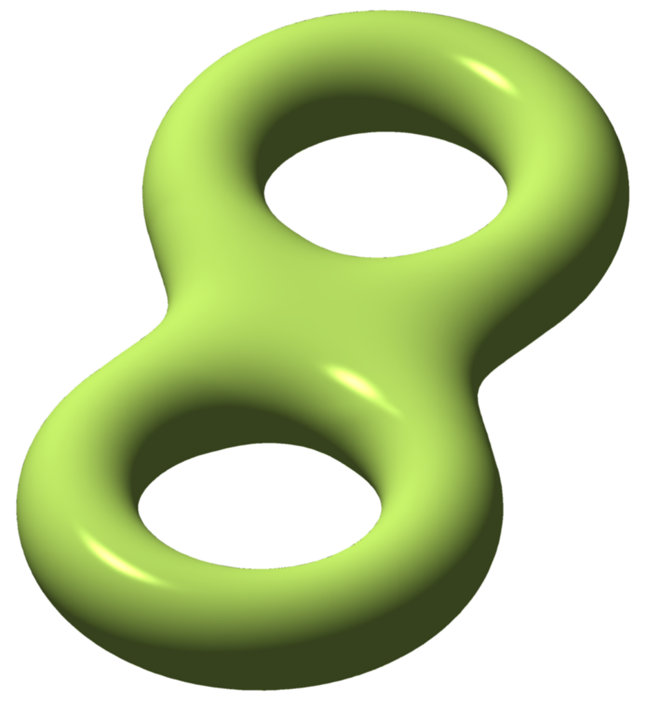

## 1. Sphere Tracing (30pts)

Code:

```python
def sphere_tracing(
    self,
    implicit_fn,
    origins, # Nx3
    directions, # Nx3
):
    '''
    Input:
        implicit_fn: a module that computes a SDF at a query point
        origins: N_rays X 3
        directions: N_rays X 3
    Output:
        points: N_rays X 3 points indicating ray-surface intersections. For rays that do not intersect the surface,
                the point can be arbitrary.
        mask: N_rays X 1 (boolean tensor) denoting which of the input rays intersect the surface.
    '''
    # TODO (Q1): Implement sphere tracing
    # 1) Iteratively update points and distance to the closest surface
    #   in order to compute intersection points of rays with the implicit surface
    # 2) Maintain a mask with the same batch dimension as the ray origins,
    #   indicating which points hit the surface, and which do not

    t = torch.ones(origins.shape[0],1).to(get_device()) * self.near    # (N_rays, 1) # Starting query points along each ray
    points = origins + t * directions

    mask = torch.ones_like(t) > 0                 # (N_rays, 1): All True, means intersecting the implicit surface (default)

    eps = 1e-5
    iteration = 0
    while True:
        iteration+=1
        f_p = implicit_fn.get_distance(points)
        t = t + f_p
        points = origins + t * directions
        mask[t > self.far] = False              # Rays that are NOT intersecting the implicit surface
        intersection_point_not_found_yet = f_p[mask] > eps

        if intersection_point_not_found_yet.sum() == 0:
            print("All the rays intersecting the implicit surface have been found!")
            break

        if iteration == self.max_iters:
            print('Maximum iteration reached!')
            break

    return points, mask
```

**Implementation of sphere tracing** : iterative method for the ray marching has been used.

pesudo code:

While(f(p)>$\epsilon$):  
t <- t + f(p)  
p <- origin + t * directions

To compute the mask, it was initialised to be True, that is intercepting with implicit surface. When marching along the ray if the distance exceeds the farthest sample point and yet has not intercepted with the implicit surface we consider the mask to be False.

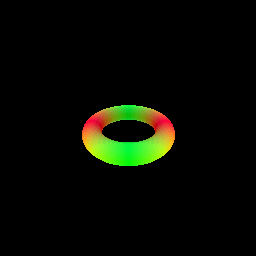